# Evaluating Winner’s Curse correction methods with a simulation study

The *mean* change in MSE over all significant SNPs across the 24 scenarios is obtained for each method:

```
##            EB          FIQT          boot           cl1           cl2
## -0.0006461667 -0.0006219583 -0.0005799167 -0.0005860000 -0.0004977083
##           cl3           rep
## -0.0005587917 -0.0006730417
```

The methods are ranked according to the results above in ascending order:

```
##   EB FIQT boot  cl1  cl2  cl3  rep
##    2    3    5    4    7    6    1
```

$~$ $~$ $~$ $~$

*Change* in MSE over all significant SNPs due to method implementation, using a significance threshold of $5 \times 10^{-4}$:

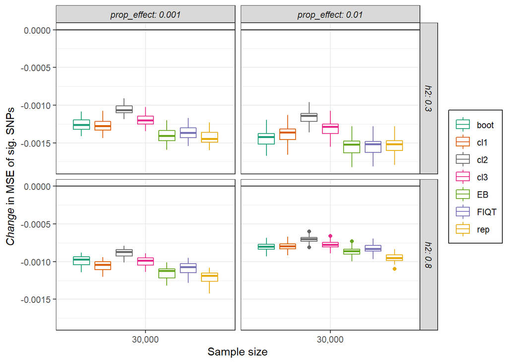

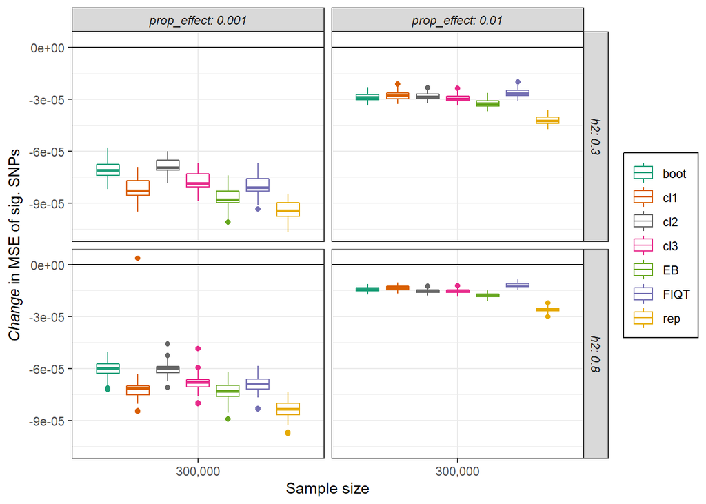

$~$ $~$ $~$ $~$

**Discussion:**

With 10 simulations for this form of distribution of effect sizes, we see that we can make very similar conclusions to those we made when the true effect sizes were normally distributed. The empirical Bayes method performs the most consistently at improving the MSE over all significant SNPs. Concerningly, all other methods tend to lead to positive values for change in MSE for the majority of cases with only the empirical Bayes method seeming to be reliable for the $5 \times 10^{-8}$ threshold.

## Binary trait with normal effect size distribution

Under the same 24 scenarios, we investigate simulating summary statistics for a *binary* trait with a normal effect size distribution and disease prevalence of 0.1 and evaluate the corresponding performance of the various Winner’s Curse adjustment methods.

Compared to the quantitative trait above, we witness a lot less SNPs meeting the significance threshold of `5e-8` under many of the scenarios.

Firstly, we plot $z$ vs $\text{bias}$ for the 8 different scenarios with a simulated binary trait and selection coefficient $S$ equal to zero.

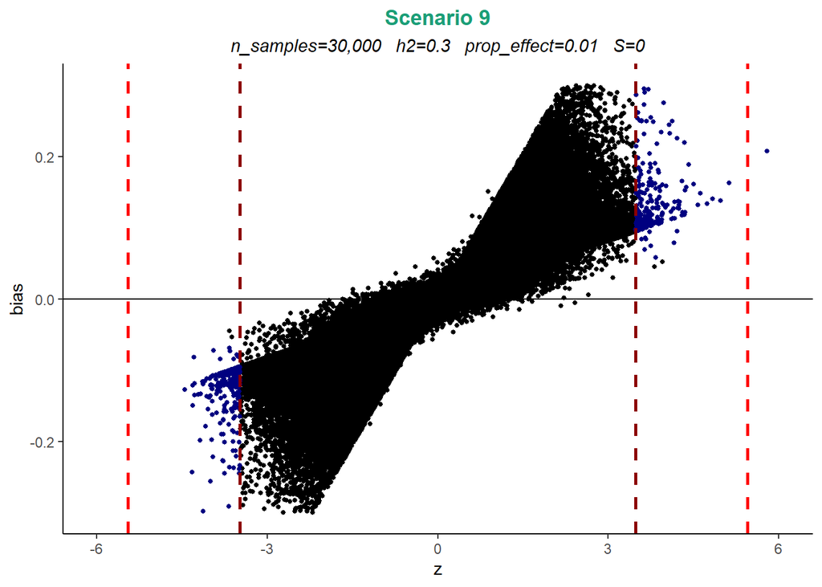

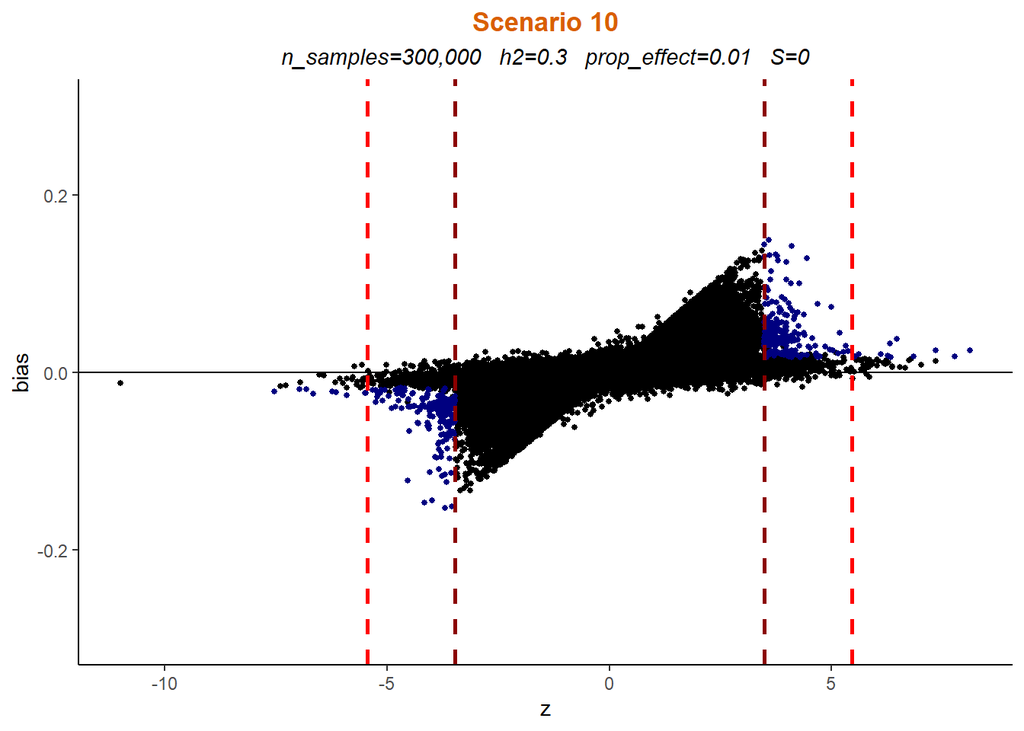

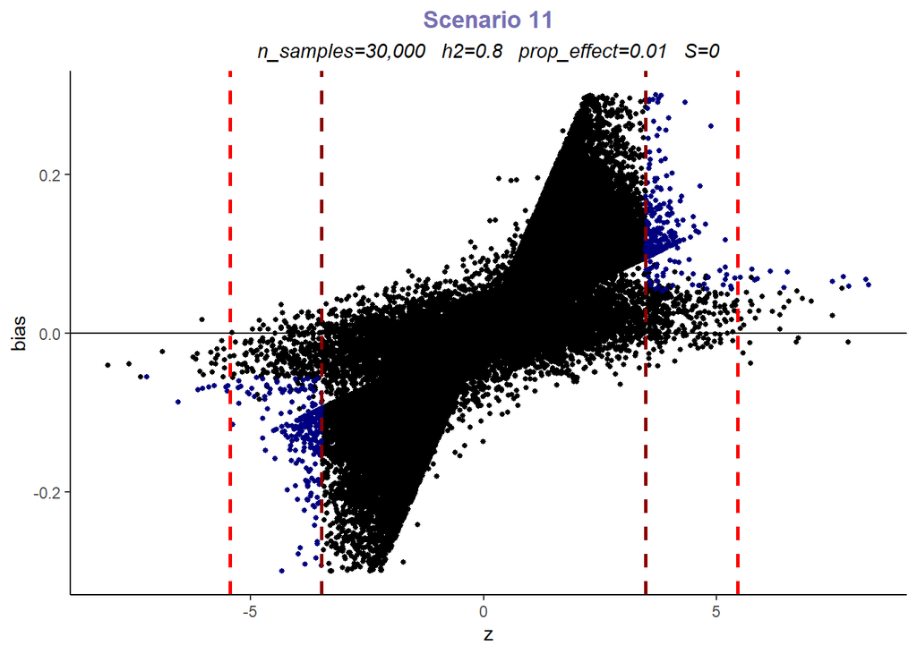

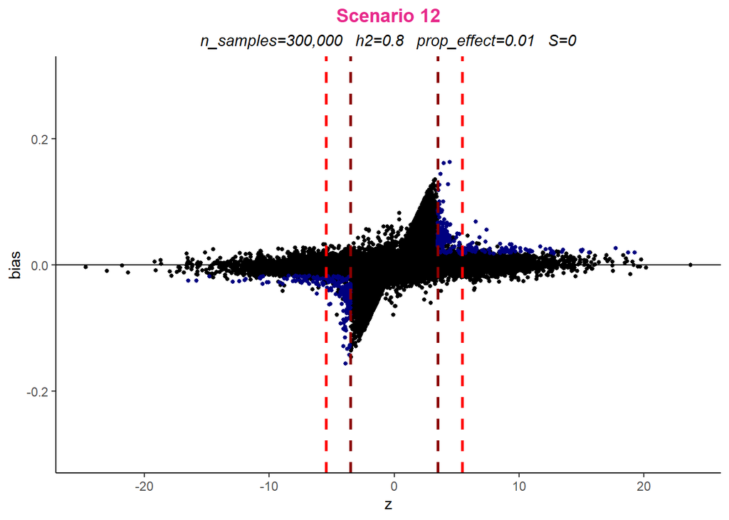

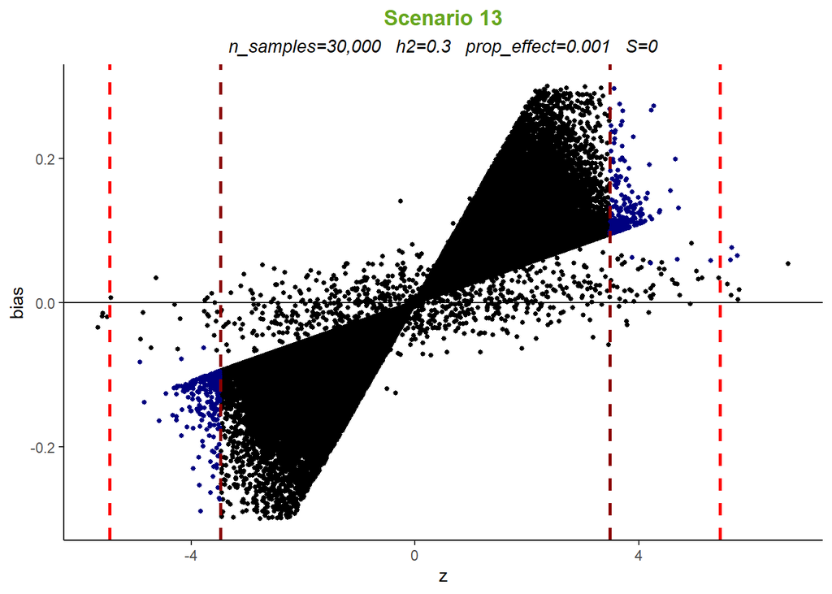

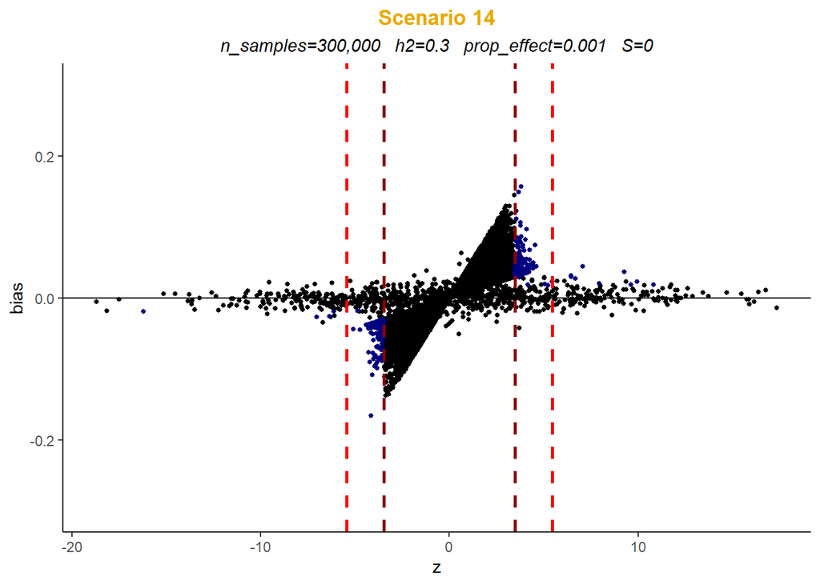

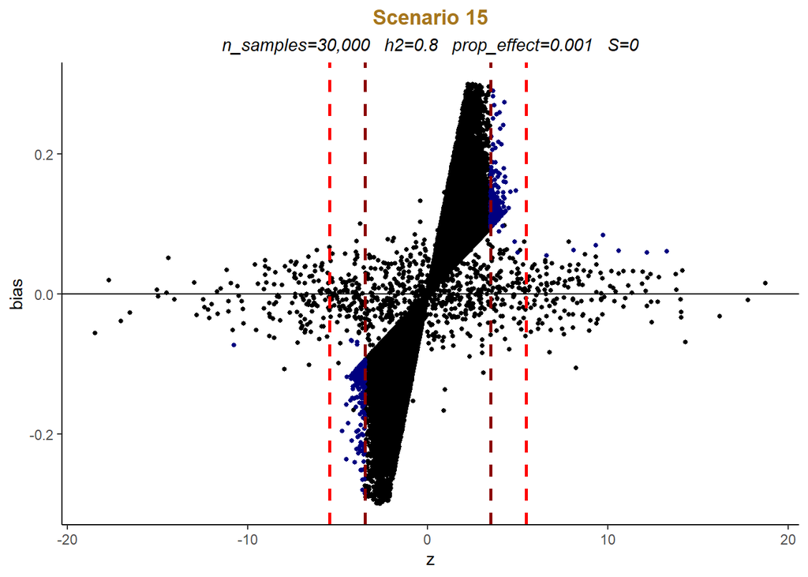

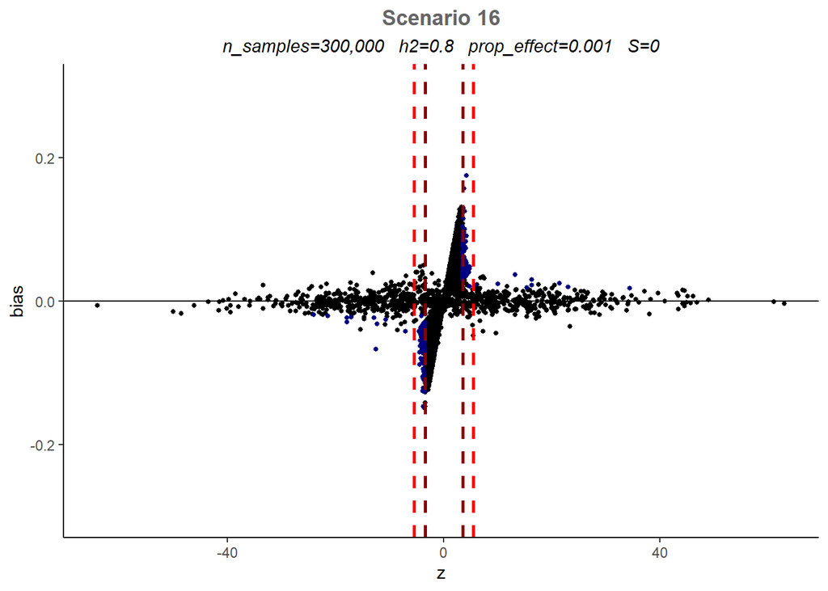

$~$ $~$

Results of using the first bias evaluation metric, `mse` with significance thresholds of $5 \times 10^{-8}$ and $5 \times 10^{-4}$, are detailed below.

**Evaluation metric 1 with threshold** $5 \times 10^{-8}$:

Summary of results for `mse` contained in `bin_5e-8_50sim_ave.csv`:

| Scenario | n_samples | h2 | prop_effect | S | EB | FIQT | boot | cl1 | cl2 | cl3 | rep |
| --- | --- | --- | --- | --- | --- | --- | --- | --- | --- | --- | --- |
| 1 | 30,000 | 0.3 | 0.010 | -1 | -0.030460 | -0.029040 | -0.032700 | -0.028914 | -0.026491 | -0.028120 | -0.035712 |
| 2 | 300,000 | 0.3 | 0.010 | -1 | -0.000390 | -0.000382 | -0.000401 | 0.000458 | -0.000165 | 0.000088 | -0.000383 |
| 3 | 30,000 | 0.8 | 0.010 | -1 | -0.003762 | -0.003575 | -0.003889 | 0.004187 | -0.001766 | 0.000617 | -0.003866 |
| 4 | 300,000 | 0.8 | 0.010 | -1 | -0.000013 | 0.000057 | 0.000002 | 0.000351 | 0.000211 | 0.000266 | -0.000010 |
| 5 | 30,000 | 0.3 | 0.001 | -1 | -0.003185 | -0.002097 | -0.000614 | 0.004208 | -0.001858 | 0.000569 | -0.003516 |
| 6 | 300,000 | 0.3 | 0.001 | -1 | -0.000003 | 0.000150 | 0.000183 | 0.000342 | 0.000197 | 0.000255 | -0.000004 |
| 7 | 30,000 | 0.8 | 0.001 | -1 | -0.000139 | 0.001418 | 0.001762 | 0.004393 | 0.002373 | 0.003188 | -0.000162 |
| 8 | 300,000 | 0.8 | 0.001 | -1 | 0.000007 | 0.000075 | 0.000075 | 0.000084 | 0.000066 | 0.000069 | 0.000001 |
| 9 | 30,000 | 0.3 | 0.010 | 0 | -0.026485 | -0.025131 | -0.026912 | -0.028769 | -0.024139 | -0.027483 | -0.028948 |
| 10 | 300,000 | 0.3 | 0.010 | 0 | -0.000137 | -0.000121 | -0.000135 | 0.000254 | -0.000014 | 0.000095 | -0.000143 |
| 11 | 30,000 | 0.8 | 0.010 | 0 | -0.001548 | -0.001434 | -0.001549 | 0.002367 | -0.000414 | 0.000715 | -0.001594 |
| 12 | 300,000 | 0.8 | 0.010 | 0 | -0.000010 | 0.000024 | -0.000005 | 0.000220 | 0.000121 | 0.000160 | -0.000011 |
| 13 | 30,000 | 0.3 | 0.001 | 0 | -0.001201 | -0.000627 | -0.000089 | 0.002136 | -0.000398 | 0.000624 | -0.001592 |
| 14 | 300,000 | 0.3 | 0.001 | 0 | -0.000006 | 0.000080 | 0.000118 | 0.000215 | 0.000119 | 0.000158 | -0.000013 |
| 15 | 30,000 | 0.8 | 0.001 | 0 | -0.000050 | 0.000815 | 0.001147 | 0.002200 | 0.001214 | 0.001601 | -0.000168 |
| 16 | 300,000 | 0.8 | 0.001 | 0 | 0.000009 | 0.000069 | 0.000073 | 0.000115 | 0.000075 | 0.000090 | 0.000000 |
| 17 | 30,000 | 0.3 | 0.010 | 1 | -0.012301 | -0.011806 | -0.012517 | -0.010239 | -0.011161 | -0.011243 | -0.013405 |
| 18 | 300,000 | 0.3 | 0.010 | 1 | -0.000101 | -0.000073 | -0.000093 | 0.000261 | 0.000027 | 0.000122 | -0.000097 |
| 19 | 30,000 | 0.8 | 0.010 | 1 | -0.001080 | -0.000848 | -0.001013 | 0.002564 | 0.000151 | 0.001136 | -0.001058 |
| 20 | 300,000 | 0.8 | 0.010 | 1 | -0.000006 | 0.000027 | 0.000001 | 0.000172 | 0.000099 | 0.000128 | -0.000008 |
| 21 | 30,000 | 0.3 | 0.001 | 1 | -0.000863 | 0.000128 | 0.000464 | 0.002403 | 0.000203 | 0.001091 | -0.001148 |
| 22 | 300,000 | 0.3 | 0.001 | 1 | -0.000002 | 0.000071 | 0.000114 | 0.000157 | 0.000089 | 0.000116 | -0.000010 |
| 23 | 30,000 | 0.8 | 0.001 | 1 | -0.000038 | 0.000752 | 0.001138 | 0.001715 | 0.000947 | 0.001254 | -0.000093 |
| 24 | 300,000 | 0.8 | 0.001 | 1 | 0.000009 | 0.000053 | 0.000058 | 0.000089 | 0.000056 | 0.000068 | -0.000002 |

$~$ $~$ $~$ $~$

The *mean* change in MSE over all significant SNPs across the 24 scenarios is obtained for each method:

```
##           EB         FIQT         boot          cl1          cl2          cl3
## -0.003406458 -0.002975625 -0.003115917 -0.001626292 -0.002519083 -0.002268167
##          rep
## -0.003830917
```

The methods are ranked according to the results above in ascending order:

```
##   EB FIQT boot  cl1  cl2  cl3  rep
##    2    4    3    7    5    6    1
```

$~$ $~$ $~$ $~$

*Change* in MSE over all significant SNPs due to method implementation, using a significance threshold of $5 \times 10^{-8}$:

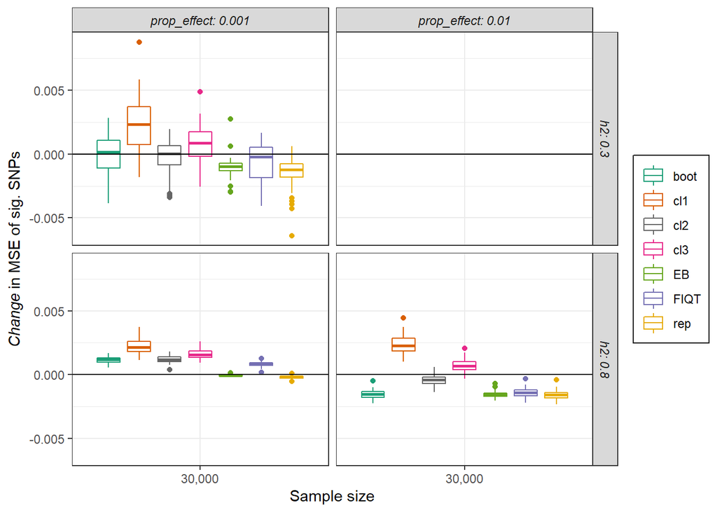

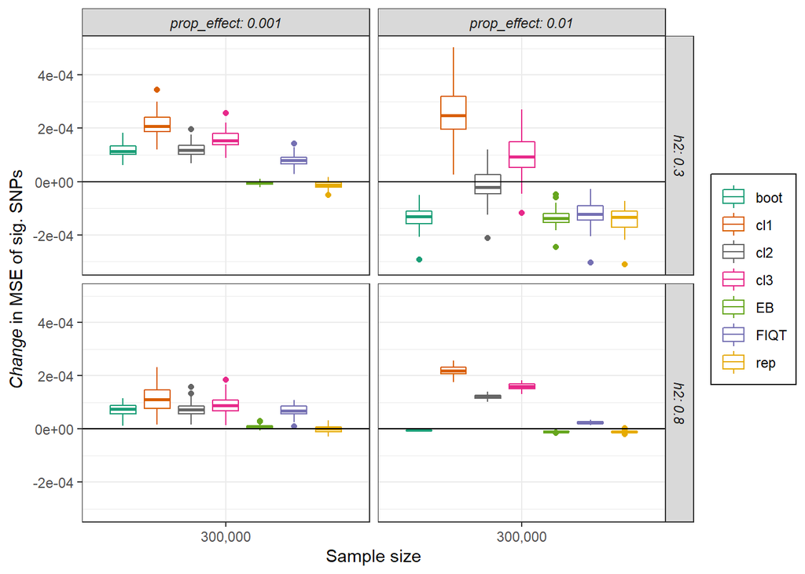

$~$ $~$ $~$ $~$

**Evaluation metric 1 with threshold** $5 \times 10^{-4}$:

Summary of results for `mse` contained in `bin_5e-4_50sim_ave.csv`:

| Scenario | n_samples | h2 | prop_effect | S | EB | FIQT | boot | cl1 | cl2 | cl3 | rep |
| --- | --- | --- | --- | --- | --- | --- | --- | --- | --- | --- | --- |
| 1 | 30,000 | 0.3 | 0.010 | -1 | -0.023689 | -0.023772 | -0.021816 | -0.020354 | -0.016692 | -0.019021 | -0.022131 |
| 2 | 300,000 | 0.3 | 0.010 | -1 | -0.000789 | -0.000754 | -0.000759 | -0.000695 | -0.000706 | -0.000735 | -0.000957 |
| 3 | 30,000 | 0.8 | 0.010 | -1 | -0.008539 | -0.008241 | -0.008247 | -0.007650 | -0.007581 | -0.007964 | -0.010145 |
| 4 | 300,000 | 0.8 | 0.010 | -1 | -0.000100 | -0.000013 | -0.000062 | -0.000046 | -0.000077 | -0.000073 | -0.000207 |
| 5 | 30,000 | 0.3 | 0.001 | -1 | -0.019515 | -0.019654 | -0.018210 | -0.017463 | -0.014574 | -0.016471 | -0.019530 |
| 6 | 300,000 | 0.3 | 0.001 | -1 | -0.000988 | -0.000882 | -0.000782 | -0.000944 | -0.000785 | -0.000895 | -0.001105 |
| 7 | 30,000 | 0.8 | 0.001 | -1 | -0.009620 | -0.008553 | -0.007615 | -0.009238 | -0.007841 | -0.008824 | -0.011116 |
| 8 | 300,000 | 0.8 | 0.001 | -1 | -0.000762 | -0.000696 | -0.000580 | -0.000747 | -0.000611 | -0.000700 | -0.000844 |
| 9 | 30,000 | 0.3 | 0.010 | 0 | -0.023170 | -0.023258 | -0.021323 | -0.019912 | -0.016301 | -0.018593 | -0.021623 |
| 10 | 300,000 | 0.3 | 0.010 | 0 | -0.000778 | -0.000776 | -0.000748 | -0.000735 | -0.000675 | -0.000732 | -0.000908 |
| 11 | 30,000 | 0.8 | 0.010 | 0 | -0.008521 | -0.008547 | -0.008205 | -0.008044 | -0.007306 | -0.007961 | -0.009798 |
| 12 | 300,000 | 0.8 | 0.010 | 0 | -0.000124 | -0.000080 | -0.000103 | -0.000086 | -0.000115 | -0.000111 | -0.000221 |
| 13 | 30,000 | 0.3 | 0.001 | 0 | -0.020029 | -0.020235 | -0.018500 | -0.017762 | -0.014699 | -0.016679 | -0.019628 |
| 14 | 300,000 | 0.3 | 0.001 | 0 | -0.001032 | -0.000966 | -0.000860 | -0.000971 | -0.000819 | -0.000923 | -0.001135 |
| 15 | 30,000 | 0.8 | 0.001 | 0 | -0.010653 | -0.009986 | -0.008955 | -0.010067 | -0.008457 | -0.009550 | -0.011628 |
| 16 | 300,000 | 0.8 | 0.001 | 0 | -0.000766 | -0.000718 | -0.000598 | -0.000770 | -0.000639 | -0.000726 | -0.000881 |
| 17 | 30,000 | 0.3 | 0.010 | 1 | -0.023481 | -0.023563 | -0.021614 | -0.020170 | -0.016508 | -0.018833 | -0.021959 |
| 18 | 300,000 | 0.3 | 0.010 | 1 | -0.000744 | -0.000742 | -0.000712 | -0.000714 | -0.000645 | -0.000705 | -0.000877 |
| 19 | 30,000 | 0.8 | 0.010 | 1 | -0.008040 | -0.008040 | -0.007681 | -0.007699 | -0.006894 | -0.007561 | -0.009322 |
| 20 | 300,000 | 0.8 | 0.010 | 1 | -0.000151 | -0.000111 | -0.000126 | -0.000138 | -0.000143 | -0.000150 | -0.000243 |
| 21 | 30,000 | 0.3 | 0.001 | 1 | -0.019944 | -0.020077 | -0.018281 | -0.017782 | -0.014631 | -0.016656 | -0.019495 |
| 22 | 300,000 | 0.3 | 0.001 | 1 | -0.001107 | -0.001047 | -0.000926 | -0.001032 | -0.000860 | -0.000974 | -0.001177 |
| 23 | 30,000 | 0.8 | 0.001 | 1 | -0.011453 | -0.010826 | -0.009631 | -0.010629 | -0.008866 | -0.010036 | -0.012089 |
| 24 | 300,000 | 0.8 | 0.001 | 1 | -0.000805 | -0.000767 | -0.000639 | -0.000794 | -0.000662 | -0.000750 | -0.000909 |

$~$ $~$ $~$ $~$

The *mean* change in MSE over all significant SNPs across the 24 scenarios is obtained for each method:

```
##           EB         FIQT         boot          cl1          cl2          cl3
## -0.008116667 -0.008012667 -0.007373875 -0.007268417 -0.006128625 -0.006900958
##          rep
## -0.008247000
```

The methods are ranked according to the results above in ascending order:

```
##   EB FIQT boot  cl1  cl2  cl3  rep
##    2    3    4    5    7    6    1
```

$~$ $~$ $~$ $~$

*Change* in MSE over all significant SNPs due to method implementation, using a significance threshold of $5 \times 10^{-4}$:

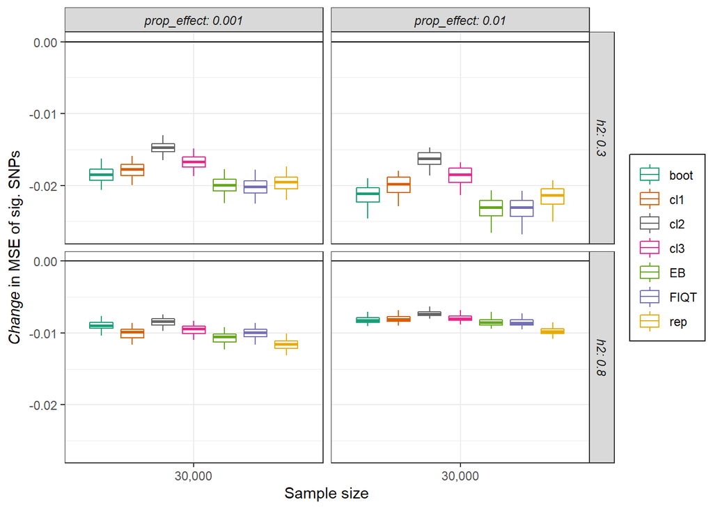

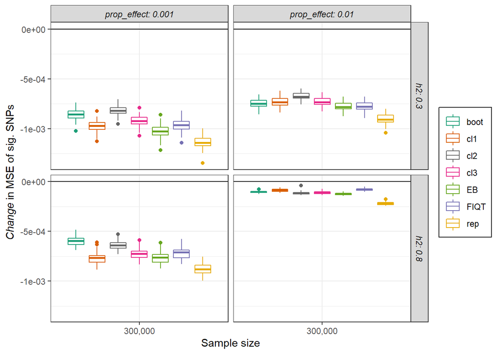

$~$ $~$ $~$ $~$

**Discussion:**

We also briefly look at the performance of methods at the lower threshold of $5 \times 10^{-4}$ for this binary trait. As one can see from the obtained plot, the results are as expected with all methods making improvements to the MSE and the empirical Bayes method being the most reliable.

# 2) Non-independent SNPs

## Introduction

Previously, we have discussed and performed a simulation study in which we simulated various sets of GWAS summary statistics and subsequently, applied several Winner’s Curse correction methods. In this study, we simulated the effect size of each SNP independently as this was the most straightforward approach. However, this is clearly not representative of the real world situation in which complicated linkage disequilibrium (LD) structures exist. Therefore, we have attempted to impose a certain LD structure on SNPs and simulate GWAS summary statistics based on this structure. Admittedly, the structure that we have chosen is very simple. That said, the following study is considered to be more reflective of the real world scenario than that which was executed previously in which SNPs were assumed to be independent. Summary statistics are reflective of a quantitative trait in which the true SNP-trait effect sizes are normally distributed.

As before, we simulate the estimated effect size, $\hat\beta_j$ for each SNP $j$ as well as its corresponding standard error, $\hat{\text{se}(\hat\beta_j)}$.

**Description of mathematical background:**

Let us assume that the true effect sizes are $\boldsymbol{b} = b_1, ..., b_S$, in which there exist a total number of $S$ SNPs. We then let $\boldsymbol{X}$ be an $N \times S$ matrix of genotypes, assumed to be mean centred, that is for each column $j: \sum_{i=1}^NX_{i,j} = 0$. We assume that genotypes $\boldsymbol{X}$ affects the $N \times 1$ response vector $Y$ through the following linear model:

$$\boldsymbol{Y} = \boldsymbol{Xb } +
\varepsilon$$

where $\varepsilon$ is a vector of independent zero mean normally distributed errors, i.e. it is assumed that $Var(\varepsilon) = \sigma^2\boldsymbol{I}$ where $\boldsymbol{I}$ denotes the $N \times N$ identity matrix.

Now, let $\boldsymbol{D} = Diag(d_1,...,d_S)$ where $d_j = \sum_{i=1}^NX^2_{i,j}$. Using the well-known identities $E(X_j^2) = \frac{\sum_{i=1}^NX^2_{i,j}}{N}$ and $var(X_j) = E(X_j^2) - (E(X_j))^2$, we have:
$$d_j = N \cdot var(X_j) = N \cdot 2
\cdot \text{maf}_j(1-\text{maf}_j)$$

as each column of genotypes is assumed to be mean centred, $E(X_j) = 0$ for each $j$ and the variance of each SNP $j$, $var(X_j)$, is assumed to take the form $var(X_j) = 2 \cdot \text{maf}_j(1-\text{maf}_j)$.

With the above definition for $\boldsymbol{D}$, the regression coefficients, $\hat\beta_1,...,\hat\beta_S$ from the marginal regression of Y on each SNP $X_j$ can be computed via the vector equation:
$$\hat\beta =
(\boldsymbol{X^TX})^{-1}\boldsymbol{X^TY} =
\boldsymbol{D}^{-1}\boldsymbol{X^TY}$$

Conditionally on the genotype matrix $X$, these estimated regression coefficients have variance-covariance matrix:

$$\boldsymbol{Cov}(\hat\beta) =
\boldsymbol{D}^{-1}\boldsymbol{X^TX}\boldsymbol{D}^{-1}\sigma^2 =
\boldsymbol{D}^{-1/2}\boldsymbol{D}^{-1/2}\boldsymbol{X^TX}\boldsymbol{D}^{-1/2}\boldsymbol{D}^{-1/2}\sigma^2
\approx
\boldsymbol{D}^{-1/2}\boldsymbol{R}\boldsymbol{D}^{-1/2}\sigma^2$$

where $\boldsymbol{R}$ is the $S \times S$ LD matrix of inter-genotype correlations, which should approximately equal the empirical correlation matrix $\boldsymbol{D^{-1/2}X^TXD^{-1/2}}$. Letting $\boldsymbol{SE}$ be the $S \times S$ diagonal matrix with element $j$ equal to $\text{se}(\hat\beta_j) = \frac{\sigma}{\sqrt{\sum_{i=1}^NX^2_{i,j}}}$, the final expression could instead be written as: $\boldsymbol{Cov}(\hat\beta) = (\boldsymbol{SE})^{1/2}\boldsymbol{R}(\boldsymbol{SE})^{1/2}$

Finally, these estimated associations are not necessarily unbiased for the true causal effects $b_1,...b_S$. Instead they are unbiased for:
$$E(\hat\beta) =
\boldsymbol{D}^{-1}\boldsymbol{X^T}E(\boldsymbol{Y}) =
\boldsymbol{D}^{-1}\boldsymbol{X^T}E(\boldsymbol{Xb} + \varepsilon) =
\boldsymbol{D}^{-1}\boldsymbol{X^TXb} =
\boldsymbol{D}^{-1/2}\boldsymbol{D}^{-1/2}\boldsymbol{X^TX}\boldsymbol{D}^{-1/2}\boldsymbol{D}^{1/2}\boldsymbol{b}
\approx
\boldsymbol{D}^{-1/2}\boldsymbol{R}\boldsymbol{D}^{1/2}\boldsymbol{b}$$

Multivariate normality of $\hat\beta$ is inherited from the assumption that $\varepsilon$ is normally distributed. In summary, conditional on the centred genotype matrix $\boldsymbol{X}$:
$$\hat\beta \sim
N(\boldsymbol{D}^{-1/2}\boldsymbol{R}\boldsymbol{D}^{1/2}\boldsymbol{b},
\boldsymbol{D}^{-1/2}\boldsymbol{R}\boldsymbol{D}^{-1/2}\sigma^2)$$

**Description of simulation method:**

Using the mathematical details provided above, the following steps were executed in order to obtain an estimated effect size, $\hat\beta_j$ and corresponding standard error, $\text{se}(\hat\beta_j)$ for SNP $j$, $j=1,...,N$. The process begins in a similar fashion as the simulation of summary statistics for independent SNPs.

1. A value is provided for $\pi$, the proportion of the total SNPs which are truly associated with the trait in question. This determines the number of effect SNPs $K = \pi \cdot N, 1 \le K \le N$, forming the polygenic background.
2. A minor allele frequency is attained for SNP $j$ using the uniform distribution $\text{maf}_j \sim U[0.01,0.5]$.
3. Assuming that the true effect sizes, $b_j$ of associated SNPs follow a Gaussian distribution with mean 0, $b_j$ is sampled for SNP $j, j=1,...,K$, from the distribution $b_j \sim N(0,[2\text{maf}_j(1-\text{maf}_j)]^S)$. Recall that $S$ is the value of the selection coefficient. Non-effect SNP $j, j = K + 1,...,N$, is simply assigned the null true effect size, $b_j = 0$.
4. Defining the heritability $h^2$ as the proportion of phenotypic variation, $var(Y)$, that is explained by all SNPs, $var(Y)$ can be computed as $var(Y) = \frac{\sum_{j=1}^K2\text{maf}_j(1-\text{maf}_j)\cdot b_j^2}{h^2}$, and following this, the true effect sizes are re-scaled giving $b_j = \frac{b_j}{\sqrt{var(Y)}}$ for $j=1,...,N$ in order to ensure a phenotype with variance 1, i.e. $\sigma = 1$.
5. Next, using the `sample` function, $K$ random positions between 1 and $N$ are chosen for the effect SNPs and the vectors containing the values of true effect size, $b_j$ and minor allele frequency, $\text{maf}_j$ are adjusted accordingly.
6. In order to reduce computation time, it is assumed that the same linkage disequilibrium structure exists in independent blocks of 100 SNPs. Therefore, for each block of 100 SNPs, the estimated effect sizes, $\hat\beta_j$ are simulated using:
   $$\hat\beta \sim
   N(\boldsymbol{D}^{-1/2}\boldsymbol{R}\boldsymbol{D}^{1/2}\boldsymbol{b},
   \boldsymbol{D}^{-1/2}\boldsymbol{R}\boldsymbol{D}^{-1/2}\sigma^2)$$
   As we have already scaled $b_j$ to ensure the phenotype has variance 1, we have $\sigma^2 = 1$. The matrix $\boldsymbol{D}$ is a diagonal $100 \times 100$ matrix, in which $d_j = n \cdot 2 \cdot \text{maf}_j(1-\text{maf}_j)$ and thus, $\boldsymbol{D}^{-1/2}$ is a similar diagonal matrix with $d^{-1/2}_j = \frac{1}{\sqrt{n \cdot 2 \cdot \text{maf}_j(1-\text{maf}_j)}}$ and $\boldsymbol{D}^{1/2}$ has diagonal entries $d^{1/2}_j = \sqrt{n \cdot 2 \cdot \text{maf}_j(1-\text{maf}_j)}$. The challenge here is to choose a suitable matrix for $\boldsymbol{R}$, the $N \times N$ LD matrix of inter-genotype correlations. For simplicity, we have chosen $\boldsymbol{R}$ to be of the following format:
   $$\begin{equation*}
   R =
   \begin{pmatrix}
   1 & \rho & \rho ^2 & \rho ^3 & \cdots & \rho^{99} \\
   \rho & 1 & \rho & \rho^2 & \cdots & \rho^{98} \\
   \rho^2 & \rho & 1 & \rho & \cdots & \rho^{97} \\
   \vdots & \vdots & \vdots & \vdots & \ddots &
   \vdots \\
   \rho^{99} & \rho^{98} & \rho^{97} & \rho^{96} & \cdots
   & 1
   \end{pmatrix}
   \end{equation*}$$
   The task is now to choose a suitable value for $\rho$. We choose a value of $\approx 0.9825$ for $\rho$ which permitted the construction of $\boldsymbol{R}$. Within each block of 100 SNPs, we then simulated values for $E(\hat\beta) = \boldsymbol{D}^{-1/2}\boldsymbol{R}\boldsymbol{D}^{1/2}\boldsymbol{b}$ and $\hat\beta$. We obtained $\hat\beta$ using the `rnorm` function with $\hat\beta = E(\hat\beta) + \boldsymbol{R}^{1/2}\boldsymbol{D}^{-1/2}\cdot$`rnorm(100)`. The standard errors for each SNP were easily obtained from the diagonal entries of $\boldsymbol{D}^{-1/2}$.
7. The above process thus provided values for $E(\hat\beta_j)$, $\hat\beta_j$ and $\text{se}(\hat\beta_j)$ for each SNP $j=1,...,N$, in which the same LD structure described by the simple matrix $\boldsymbol{R}$ has been imposed for each independent block of 100 SNPs.

Firstly, in order to gain a better insight into the various scenarios by means of different combinations of the previously mentioned parameter, we simulate a single set of GWAS summary statistics and plot $z$ vs $\text{bias}$ in which $z = \frac{\hat\beta}{\text{se}(\hat\beta)}$ and $\text{bias} = \hat\beta - E(\hat\beta)$ for each of the 8 different scenarios when the selection coefficient, S is fixed at 0. On all figures, the bright red line corresponds to the significance threshold of $5 \times 10^{-8}$ while the darker red line relates to $5 \times 10^{-4}$. The points corresponding to SNPs which are *significantly* overestimated and are significant at a threshold of $5 \times 10^{-4}$ are coloured in navy.

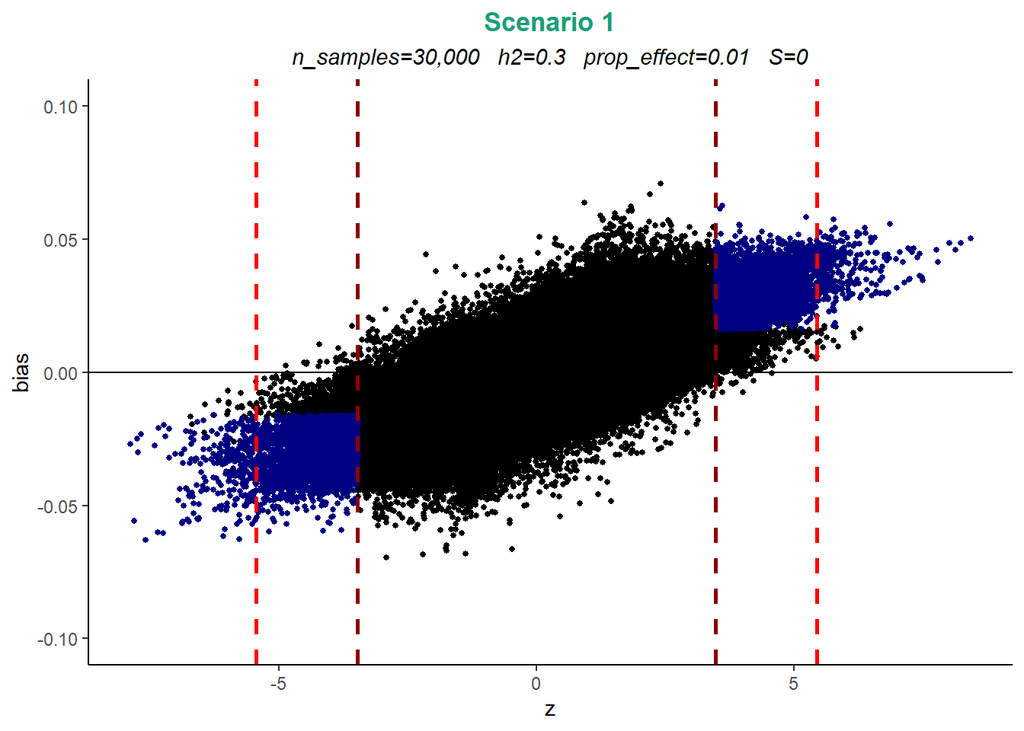

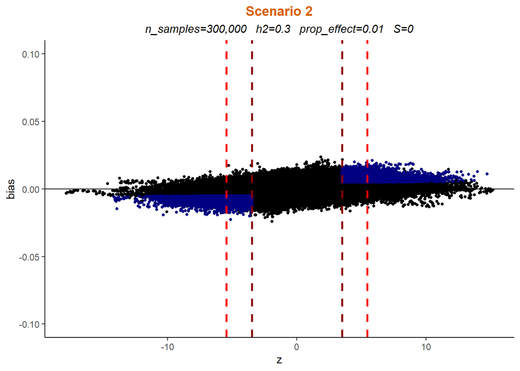

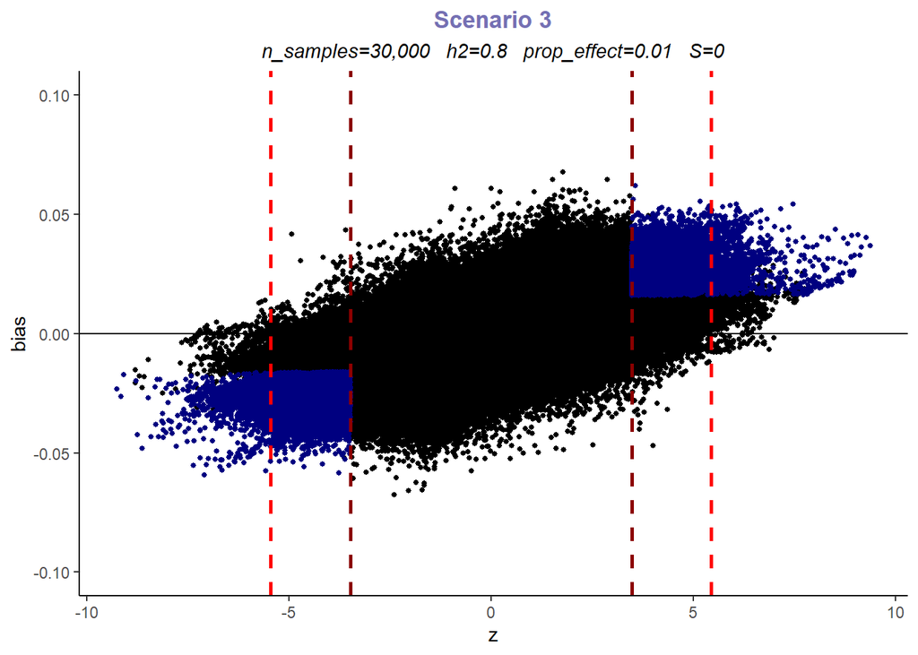

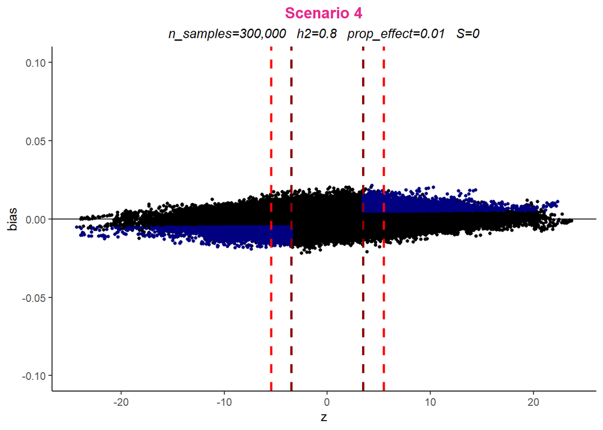

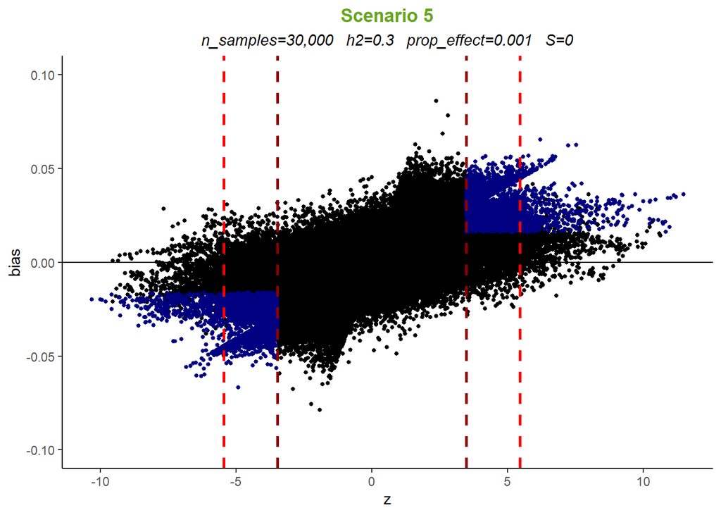

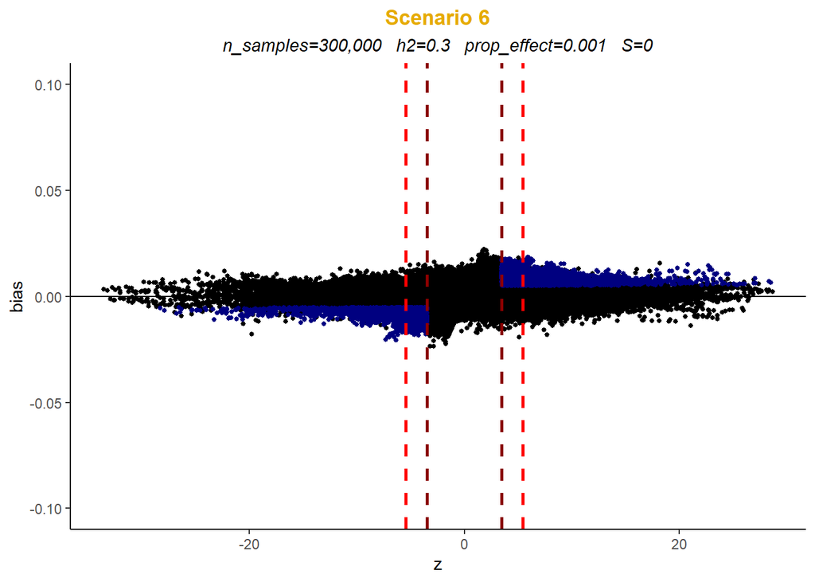

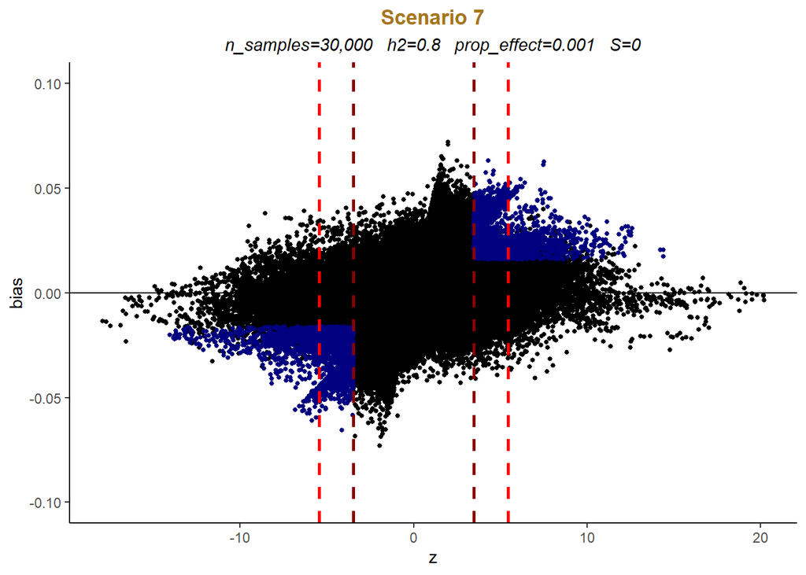

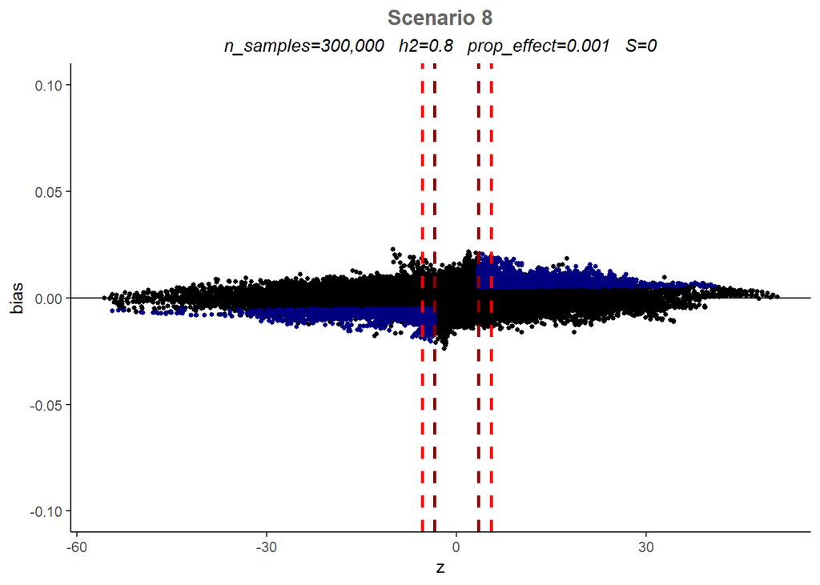

$~$ $~$

In a similar manner to the preliminary investigation of the first part of this extensive study, over a total of 10 simulations, we look at the number of significant SNPs, the proportion of these SNPs that have association estimates more extreme than their true effect size, the proportion of these SNPs which are *significantly* overestimated and the MSE of significant SNPs at the common genome-wide significance threshold of $5 \times 10^{-8}$. Large values for the proportion of *significantly* overestimated SNPs and the MSE of significant SNPs provide evidence for a great degree of bias induced by Winner’s Curse.

Running the code provided in `nsig_prop_bias_LD_100sim.R`, we obtain the following results:

| Scenario | n_samples | h2 | prop_effect | S | n_sig 5e-8 | prop_bias 5e-8 | prop_x 5e-8 | mse 5e-8 | sd(n_sig) 5e-8 | sd(prop_bias) 5e-8 | sd(prop_x) 5e-8 | sd(mse) 5e-8 |
| --- | --- | --- | --- | --- | --- | --- | --- | --- | --- | --- | --- | --- |
| 1 | 30,000 | 0.3 | 0.010 | 0 | 555.16 | 0.9990 | 0.9326 | 0.001460 | 77.038 | 0.0034 | 0.0468 | 1.3e-04 |
| 2 | 300,000 | 0.3 | 0.010 | 0 | 33835.62 | 0.7771 | 0.2138 | 0.000025 | 903.788 | 0.0111 | 0.0102 | 1.0e-06 |
| 3 | 30,000 | 0.8 | 0.010 | 0 | 3268.78 | 0.9523 | 0.5715 | 0.000621 | 296.099 | 0.0155 | 0.0356 | 4.3e-05 |
| 4 | 300,000 | 0.8 | 0.010 | 0 | 103021.40 | 0.6684 | 0.1300 | 0.000019 | 1560.175 | 0.0087 | 0.0050 | 0.0e+00 |
| 5 | 30,000 | 0.3 | 0.001 | 0 | 2953.30 | 0.8339 | 0.3064 | 0.000398 | 199.704 | 0.0359 | 0.0377 | 4.7e-05 |
| 6 | 300,000 | 0.3 | 0.001 | 0 | 29983.24 | 0.6088 | 0.0998 | 0.000018 | 753.342 | 0.0161 | 0.0084 | 1.0e-06 |
| 7 | 30,000 | 0.8 | 0.001 | 0 | 10445.11 | 0.7091 | 0.1655 | 0.000231 | 353.861 | 0.0237 | 0.0164 | 1.6e-05 |
| 8 | 300,000 | 0.8 | 0.001 | 0 | 47188.51 | 0.5651 | 0.0805 | 0.000017 | 916.009 | 0.0147 | 0.0063 | 1.0e-06 |

$~$ $~$ $~$

We show how the number of significant SNPs differs for the 8 different scenarios with $S=0$ at the significance threshold $5 \times 10^{-8}$:

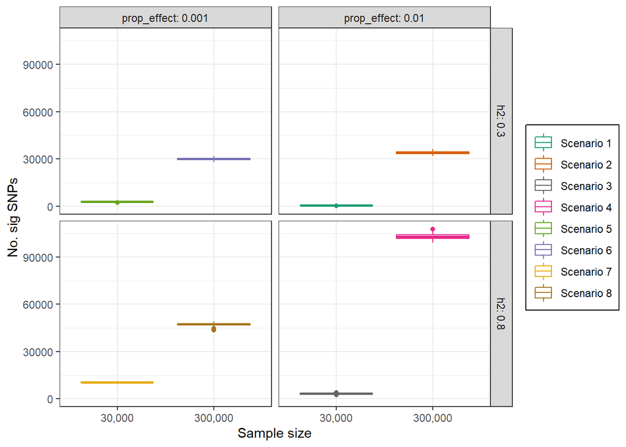

We can also visualise the proportion of significant SNPs that are *significantly* overestimated and the MSE of significant SNPs at the significance threshold of $5 \times 10^{-8}$ as follows:

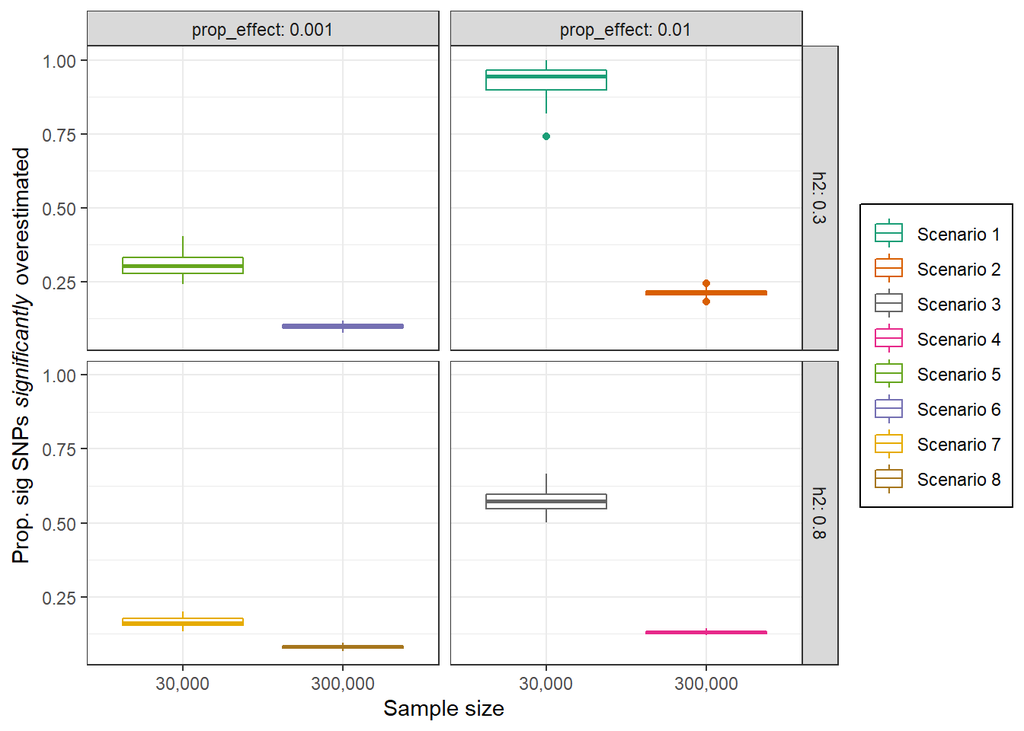

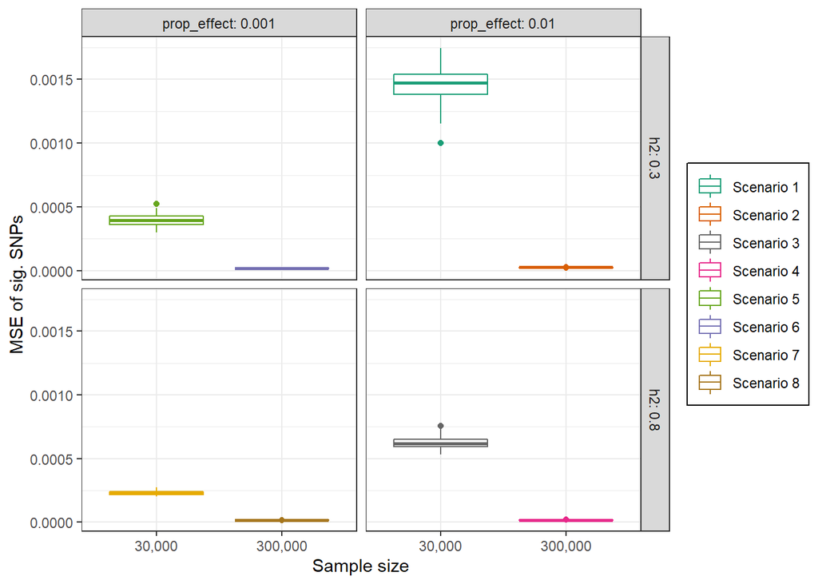

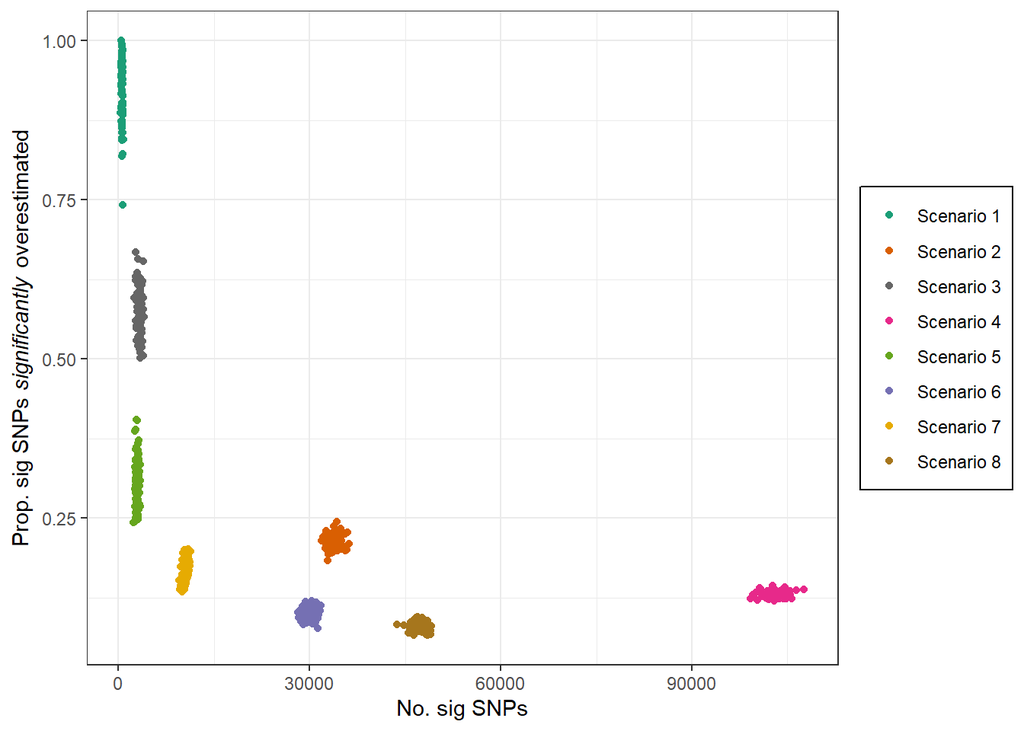

## Application of Winner’s Curse correction methods

Using the code detailed in `winnerscurse_sims_LD.R` and a total of 100 simulations, we evaluate the different Winner’s Curse methods across each of the 8 scenarios. The methods to be compared include three conditional likelihood methods, FDR Inverse Quantile Transformation, the modified bootstrap method as well as five versions of the Empirical Bayes method. The following four bias evaluation metrics are used, with the first and second perhaps being the most important:

1. The change in MSE of significant SNPs due to method implementation - `mse`
2. The change in RMSE of significant SNPs due to method implementation - `rmse`
3. The *relative* change in MSE of significant SNPs due to method implementation - `rel_mse`
4. The fraction of significant SNPs in which their association estimates have been improved due to method implementation - `flb`

The formal mathematical definitions of these evaluation metrics may be found in the document which discussed simulating summary statistics of independent SNPs, with $E(\beta_i)$ replacing $\beta_i$.

**Evaluation metric 1 with threshold** $5 \times 10^{-8}$:

Summary of results for `mse` contained in `norm_5e-8_100sim_LD_ave.csv`:

| Scenario | n_samples | h2 | prop_effect | S | EB | EB_df | EB_scam | EB_gam_po | EB_gam_nb | FIQT | boot | cl1 | cl2 | cl3 |
| --- | --- | --- | --- | --- | --- | --- | --- | --- | --- | --- | --- | --- | --- | --- |
| 1 | 30,000 | 0.3 | 0.010 | 0 | -0.000866 | -0.000945 | -0.000894 | -0.000851 | -0.000869 | -0.000806 | -0.000871 | -0.000806 | -0.000932 | -0.000899 |
| 2 | 300,000 | 0.3 | 0.010 | 0 | -0.000007 | -0.000006 | -0.000007 | -0.000006 | -0.000007 | -0.000007 | -0.000007 | 0.000041 | 0.000016 | 0.000026 |
| 3 | 30,000 | 0.8 | 0.010 | 0 | -0.000321 | -0.000325 | -0.000325 | -0.000331 | -0.000329 | -0.000313 | -0.000325 | 0.000057 | -0.000236 | -0.000120 |
| 4 | 300,000 | 0.8 | 0.010 | 0 | -0.000002 | -0.000001 | -0.000002 | -0.000002 | -0.000002 | -0.000002 | -0.000002 | 0.000033 | 0.000018 | 0.000024 |
| 5 | 30,000 | 0.3 | 0.001 | 0 | -0.000124 | -0.000114 | -0.000128 | -0.000131 | -0.000131 | -0.000135 | -0.000134 | 0.000306 | 0.000040 | 0.000146 |
| 6 | 300,000 | 0.3 | 0.001 | 0 | -0.000001 | 0.000004 | -0.000001 | 0.000008 | 0.000000 | 0.000000 | -0.000001 | 0.000023 | 0.000014 | 0.000017 |
| 7 | 30,000 | 0.8 | 0.001 | 0 | -0.000035 | -0.000007 | -0.000034 | -0.000020 | -0.000034 | -0.000026 | -0.000036 | 0.000347 | 0.000163 | 0.000236 |
| 8 | 300,000 | 0.8 | 0.001 | 0 | 0.000000 | 0.000002 | 0.000000 | 0.000011 | 0.000000 | 0.000001 | 0.000000 | 0.000015 | 0.000010 | 0.000012 |

$~$ $~$ $~$ $~$

The *mean* change in MSE over all significant SNPs across the 8 scenarios is obtained for each method:

```
##           EB        EB_df      EB_scam    EB_gam_po    EB_gam_nb         FIQT
## -0.000169500 -0.000174000 -0.000173875 -0.000165250 -0.000171500 -0.000161000
##         boot          cl1          cl2          cl3
## -0.000172000  0.000002000 -0.000113375 -0.000069750
```

The methods are ranked according to the results above in ascending order:

```
##        EB     EB_df   EB_scam EB_gam_po EB_gam_nb      FIQT      boot       cl1
##         5         1         2         6         4         7         3        10
##       cl2       cl3
##         8         9
```

$~$ $~$ $~$ $~$

*Change* in MSE over all significant SNPs due to method implementation, using a significance threshold of $5 \times 10^{-8}$:

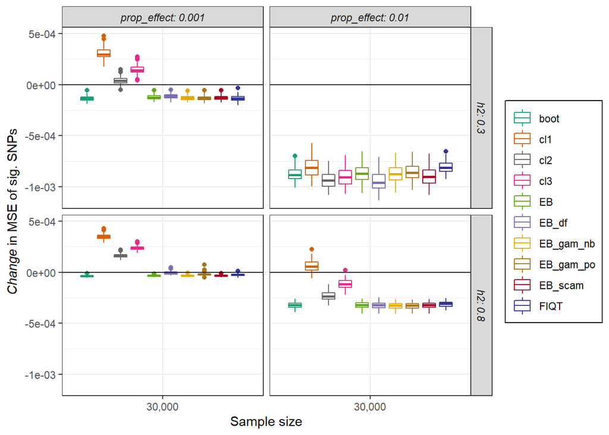

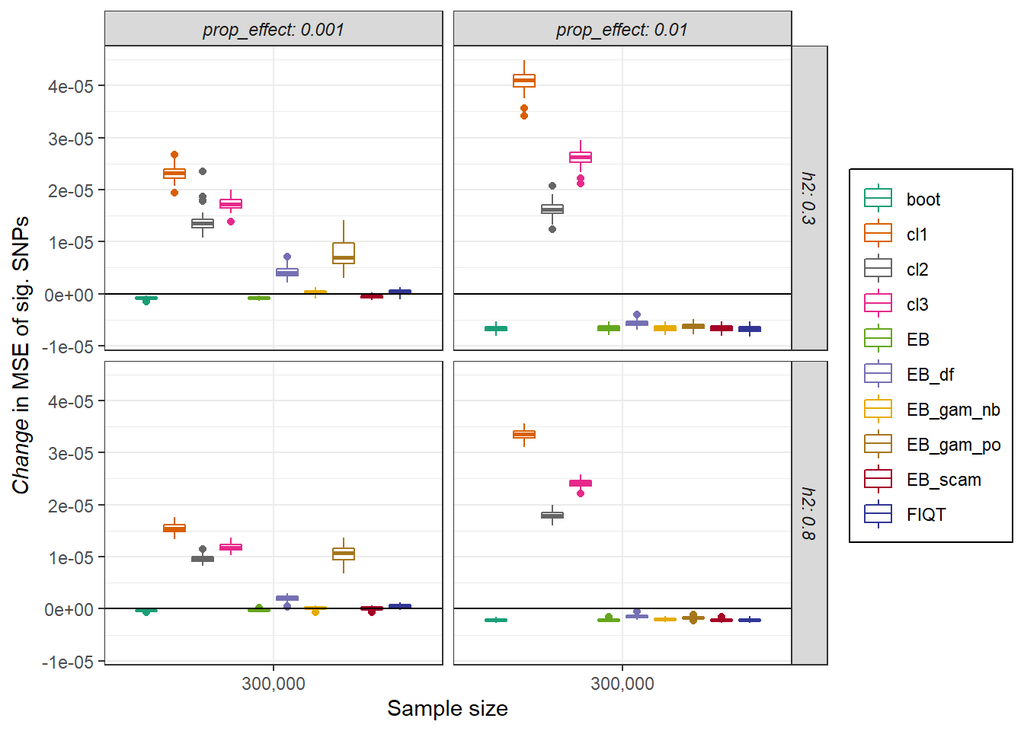

$~$ $~$ $~$ $~$

**Evaluation metric 2 with threshold** $5 \times 10^{-8}$:

Summary of results for `rmse` contained in `norm_5e-8_100sim_LD_ave.csv`:

| Scenario | n_samples | h2 | prop_effect | S | EB | EB_df | EB_scam | EB_gam_po | EB_gam_nb | FIQT | boot | cl1 | cl2 | cl3 |
| --- | --- | --- | --- | --- | --- | --- | --- | --- | --- | --- | --- | --- | --- | --- |
| 1 | 30,000 | 0.3 | 0.010 | 0 | -0.014022 | -0.015720 | -0.014599 | -0.013693 | -0.014058 | -0.012778 | -0.014090 | -0.012754 | -0.015427 | -0.014689 |
| 2 | 300,000 | 0.3 | 0.010 | 0 | -0.000716 | -0.000608 | -0.000719 | -0.000672 | -0.000714 | -0.000728 | -0.000724 | 0.003117 | 0.001426 | 0.002156 |
| 3 | 30,000 | 0.8 | 0.010 | 0 | -0.007761 | -0.007888 | -0.007870 | -0.008045 | -0.008002 | -0.007513 | -0.007863 | 0.001147 | -0.005379 | -0.002562 |
| 4 | 300,000 | 0.8 | 0.010 | 0 | -0.000254 | -0.000170 | -0.000254 | -0.000201 | -0.000243 | -0.000255 | -0.000256 | 0.002903 | 0.001739 | 0.002224 |
| 5 | 30,000 | 0.3 | 0.001 | 0 | -0.003408 | -0.003103 | -0.003543 | -0.003633 | -0.003610 | -0.003740 | -0.003723 | 0.006610 | 0.000981 | 0.003399 |
| 6 | 300,000 | 0.3 | 0.001 | 0 | -0.000102 | 0.000475 | -0.000070 | 0.000828 | 0.000030 | 0.000030 | -0.000101 | 0.002188 | 0.001406 | 0.001714 |
| 7 | 30,000 | 0.8 | 0.001 | 0 | -0.001214 | -0.000244 | -0.001160 | -0.000677 | -0.001173 | -0.000883 | -0.001241 | 0.008853 | 0.004661 | 0.006430 |
| 8 | 300,000 | 0.8 | 0.001 | 0 | -0.000025 | 0.000240 | 0.000012 | 0.001126 | 0.000018 | 0.000066 | -0.000037 | 0.001579 | 0.001042 | 0.001252 |

$~$ $~$ $~$ $~$

The *mean* change in RMSE over all significant SNPs across the 8 scenarios is obtained for each method:

```
##           EB        EB_df      EB_scam    EB_gam_po    EB_gam_nb         FIQT
## -0.003437750 -0.003377250 -0.003525375 -0.003120875 -0.003469000 -0.003225125
##         boot          cl1          cl2          cl3
## -0.003504375  0.001705375 -0.001193875 -0.000009500
```

The methods are ranked according to the results above in ascending order:

```
##        EB     EB_df   EB_scam EB_gam_po EB_gam_nb      FIQT      boot       cl1
##         4         5         1         7         3         6         2        10
##       cl2       cl3
##         8         9
```

$~$ $~$ $~$ $~$

*Change* in RMSE over all significant SNPs due to method implementation, using a significance threshold of $5 \times 10^{-8}$:

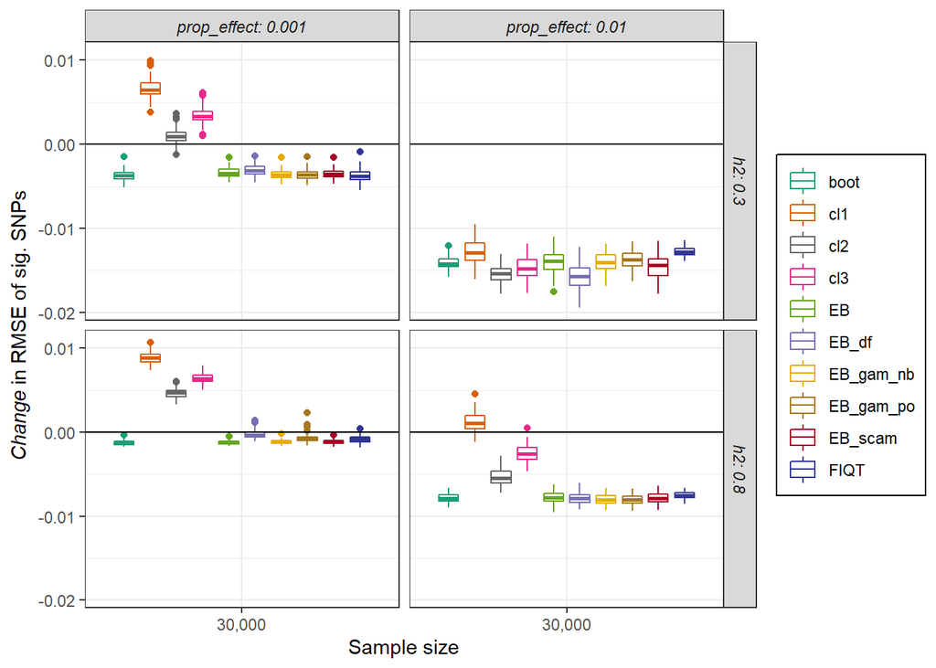

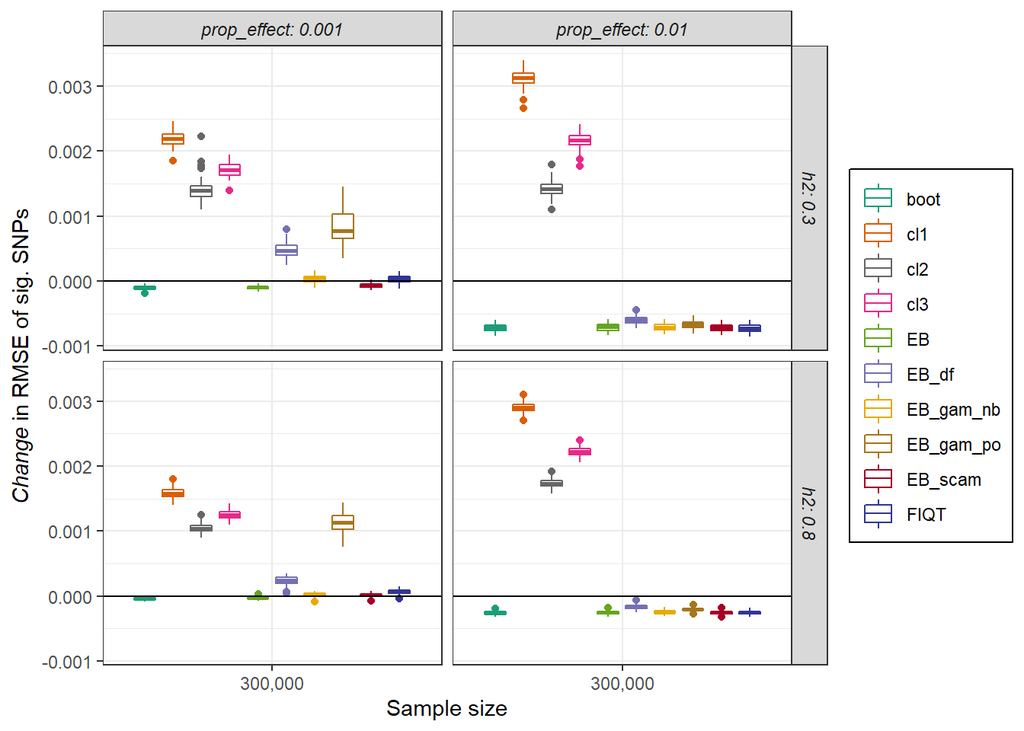

$~$ $~$ $~$ $~$

**Evaluation metric 3 with threshold** $5 \times 10^{-8}$:

Summary of results for `rel_mse` contained in `norm_5e-8_100sim_LD_ave.csv`:

| Scenario | n_samples | h2 | prop_effect | S | EB | EB_df | EB_scam | EB_gam_po | EB_gam_nb | FIQT | boot | cl1 | cl2 | cl3 |
| --- | --- | --- | --- | --- | --- | --- | --- | --- | --- | --- | --- | --- | --- | --- |
| 1 | 30,000 | 0.3 | 0.010 | 0 | -0.6021 | -0.6562 | -0.6209 | -0.5916 | -0.6037 | -0.5607 | -0.6051 | -0.5581 | -0.6479 | -0.6239 |
| 2 | 300,000 | 0.3 | 0.010 | 0 | -0.2657 | -0.2282 | -0.2669 | -0.2507 | -0.2650 | -0.2700 | -0.2687 | 1.6391 | 0.6539 | 1.0508 |
| 3 | 30,000 | 0.8 | 0.010 | 0 | -0.5315 | -0.5384 | -0.5376 | -0.5473 | -0.5449 | -0.5180 | -0.5374 | 0.1008 | -0.3879 | -0.1944 |
| 4 | 300,000 | 0.8 | 0.010 | 0 | -0.1144 | -0.0770 | -0.1143 | -0.0911 | -0.1096 | -0.1146 | -0.1152 | 1.8003 | 0.9694 | 1.2980 |
| 5 | 30,000 | 0.3 | 0.001 | 0 | -0.3127 | -0.2869 | -0.3239 | -0.3311 | -0.3295 | -0.3388 | -0.3384 | 0.7879 | 0.1071 | 0.3796 |
| 6 | 300,000 | 0.3 | 0.001 | 0 | -0.0481 | 0.2406 | -0.0329 | 0.4380 | 0.0145 | 0.0148 | -0.0474 | 1.3182 | 0.7850 | 0.9866 |
| 7 | 30,000 | 0.8 | 0.001 | 0 | -0.1532 | -0.0300 | -0.1468 | -0.0857 | -0.1481 | -0.1117 | -0.1564 | 1.5149 | 0.7134 | 1.0328 |
| 8 | 300,000 | 0.8 | 0.001 | 0 | -0.0122 | 0.1212 | 0.0060 | 0.6273 | 0.0092 | 0.0327 | -0.0177 | 0.9210 | 0.5747 | 0.7060 |

$~$ $~$ $~$ $~$

The *mean* relative change in MSE over all significant SNPs across the 8 scenarios is obtained for each method:

```
##         EB      EB_df    EB_scam  EB_gam_po  EB_gam_nb       FIQT       boot
## -0.2549875 -0.1818625 -0.2546625 -0.1040250 -0.2471375 -0.2332875 -0.2607875
##        cl1        cl2        cl3
##  0.9405125  0.3459625  0.5794375
```

The methods are ranked according to the results above in ascending order:

```
##        EB     EB_df   EB_scam EB_gam_po EB_gam_nb      FIQT      boot       cl1
##         2         6         3         7         4         5         1        10
##       cl2       cl3
##         8         9
```

$~$ $~$ $~$ $~$

*Relative change* in MSE over all significant SNPs due to method implementation, using a significance threshold of $5 \times 10^{-8}$:

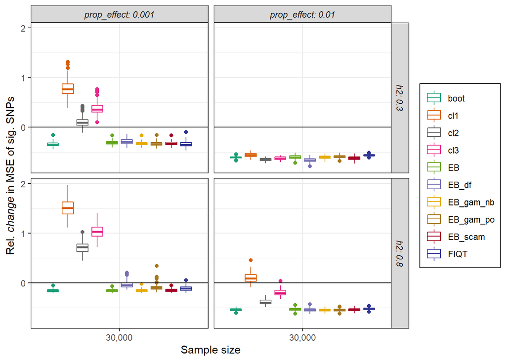

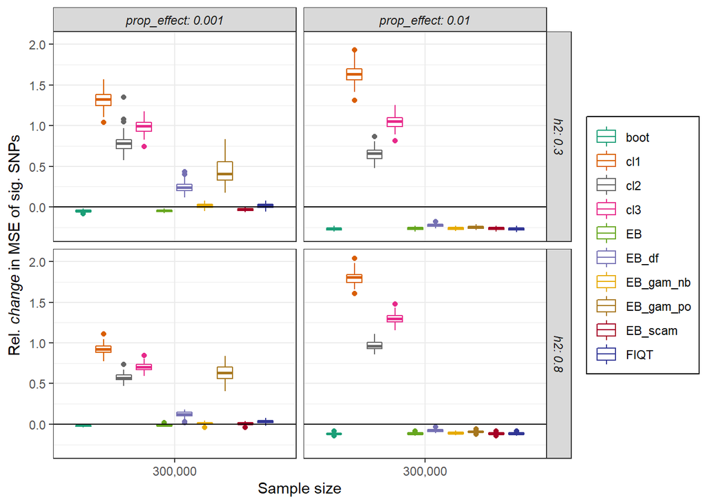

$~$ $~$ $~$ $~$

**Evaluation metric 4 with threshold** $5 \times 10^{-8}$:

Summary of results for `flb` contained in `norm_5e-8_100sim_LD_ave.csv`:

| Scenario | n_samples | h2 | prop_effect | S | EB | EB_df | EB_scam | EB_gam_po | EB_gam_nb | FIQT | boot | cl1 | cl2 | cl3 |
| --- | --- | --- | --- | --- | --- | --- | --- | --- | --- | --- | --- | --- | --- | --- |
| 1 | 30,000 | 0.3 | 0.010 | 0 | 0.9864 | 0.9862 | 0.9889 | 0.9896 | 0.9892 | 0.9911 | 0.9893 | 0.9441 | 0.9779 | 0.9665 |
| 2 | 300,000 | 0.3 | 0.010 | 0 | 0.6867 | 0.7018 | 0.6889 | 0.6941 | 0.6911 | 0.6844 | 0.6871 | 0.5995 | 0.5883 | 0.5920 |
| 3 | 30,000 | 0.8 | 0.010 | 0 | 0.8694 | 0.8707 | 0.8713 | 0.8656 | 0.8682 | 0.8794 | 0.8728 | 0.7427 | 0.7925 | 0.7675 |
| 4 | 300,000 | 0.8 | 0.010 | 0 | 0.6075 | 0.5696 | 0.6096 | 0.6097 | 0.5975 | 0.6001 | 0.6073 | 0.5544 | 0.5319 | 0.5433 |
| 5 | 30,000 | 0.3 | 0.001 | 0 | 0.7310 | 0.7471 | 0.7346 | 0.7219 | 0.7333 | 0.6977 | 0.7209 | 0.6429 | 0.6417 | 0.6409 |
| 6 | 300,000 | 0.3 | 0.001 | 0 | 0.5668 | 0.4042 | 0.5570 | 0.3357 | 0.5286 | 0.5187 | 0.5612 | 0.5348 | 0.5086 | 0.5259 |
| 7 | 30,000 | 0.8 | 0.001 | 0 | 0.6320 | 0.4492 | 0.6388 | 0.6252 | 0.6294 | 0.5824 | 0.6225 | 0.5725 | 0.5529 | 0.5616 |
| 8 | 300,000 | 0.8 | 0.001 | 0 | 0.4888 | 0.4361 | 0.5246 | 0.3265 | 0.5148 | 0.4975 | 0.5384 | 0.5230 | 0.4951 | 0.5164 |

$~$ $~$ $~$ $~$

The *mean* fraction of significant SNPs with improved association estimates due to method implementation across the 8 scenarios is obtained for each method:

```
##        EB     EB_df   EB_scam EB_gam_po EB_gam_nb      FIQT      boot       cl1
## 0.6960750 0.6456125 0.7017125 0.6460375 0.6940125 0.6814125 0.6999375 0.6392375
##       cl2       cl3
## 0.6361125 0.6392625
```

The methods are ranked according to the results above in descending order:

```
##        EB     EB_df   EB_scam EB_gam_po EB_gam_nb      FIQT      boot       cl1
##         3         7         1         6         4         5         2         9
##       cl2       cl3
##        10         8
```

$~$ $~$ $~$ $~$

Fraction of significant SNPs with improved association estimates due to method implementation, using a significance threshold of $5 \times 10^{-8}$:

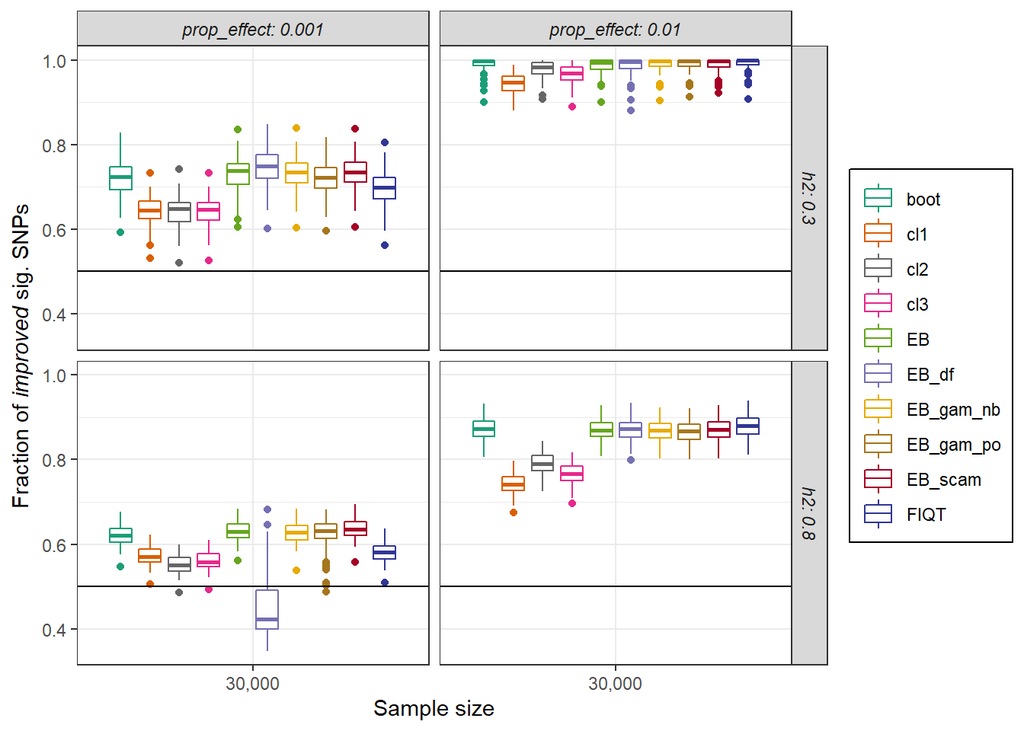

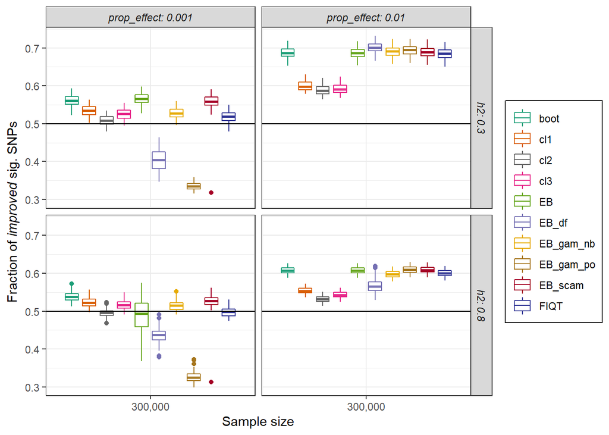

$~$ $~$ $~$ $~$

**Evaluation metric 2 with threshold** $5 \times 10^{-4}$:

Summary of results for `rmse` contained in `norm_5e-4_100sim_LD_ave.csv`:

| Scenario | n_samples | h2 | prop_effect | S | EB | EB_df | EB_scam | EB_gam_po | EB_gam_nb | FIQT | boot | cl1 | cl2 | cl3 |
| --- | --- | --- | --- | --- | --- | --- | --- | --- | --- | --- | --- | --- | --- | --- |
| 1 | 30,000 | 0.3 | 0.010 | 0 | -0.012711 | -0.012330 | -0.012816 | -0.012895 | -0.012813 | -0.011317 | -0.011630 | -0.009565 | -0.010104 | -0.010252 |
| 2 | 300,000 | 0.3 | 0.010 | 0 | -0.000697 | -0.000651 | -0.000700 | -0.000683 | -0.000701 | -0.000703 | -0.000702 | 0.001145 | 0.000023 | 0.000501 |
| 3 | 30,000 | 0.8 | 0.010 | 0 | -0.007196 | -0.007007 | -0.007199 | -0.007168 | -0.007174 | -0.006862 | -0.007018 | -0.002652 | -0.005838 | -0.004626 |
| 4 | 300,000 | 0.8 | 0.010 | 0 | -0.000266 | -0.000200 | -0.000265 | -0.000212 | -0.000254 | -0.000265 | -0.000267 | 0.001324 | 0.000508 | 0.000846 |
| 5 | 30,000 | 0.3 | 0.001 | 0 | -0.006605 | -0.006539 | -0.006562 | -0.006375 | -0.006551 | -0.006565 | -0.006536 | -0.004908 | -0.006345 | -0.005981 |
| 6 | 300,000 | 0.3 | 0.001 | 0 | -0.000538 | -0.000178 | -0.000502 | 0.000020 | -0.000347 | -0.000444 | -0.000537 | -0.000090 | -0.000457 | -0.000343 |
| 7 | 30,000 | 0.8 | 0.001 | 0 | -0.003446 | -0.003159 | -0.003496 | -0.003403 | -0.003471 | -0.003294 | -0.003446 | -0.001573 | -0.003298 | -0.002724 |
| 8 | 300,000 | 0.8 | 0.001 | 0 | -0.000398 | -0.000058 | -0.000322 | 0.000366 | -0.000134 | -0.000300 | -0.000406 | -0.000147 | -0.000384 | -0.000317 |

$~$ $~$ $~$ $~$

The *mean* change in RMSE over all significant SNPs across the 8 scenarios is obtained for each method:

```
##           EB        EB_df      EB_scam    EB_gam_po    EB_gam_nb         FIQT
## -0.003982125 -0.003765250 -0.003982750 -0.003793750 -0.003930625 -0.003718750
##         boot          cl1          cl2          cl3
## -0.003817750 -0.002058250 -0.003236875 -0.002862000
```

The methods are ranked according to the results above in ascending order:

```
##        EB     EB_df   EB_scam EB_gam_po EB_gam_nb      FIQT      boot       cl1
##         2         6         1         5         3         7         4        10
##       cl2       cl3
##         8         9
```

$~$ $~$ $~$ $~$

*Change* in RMSE over all significant SNPs due to method implementation, using a significance threshold of $5 \times 10^{-4}$:

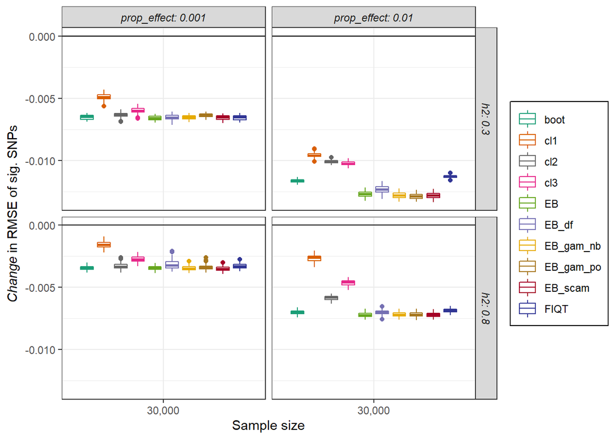

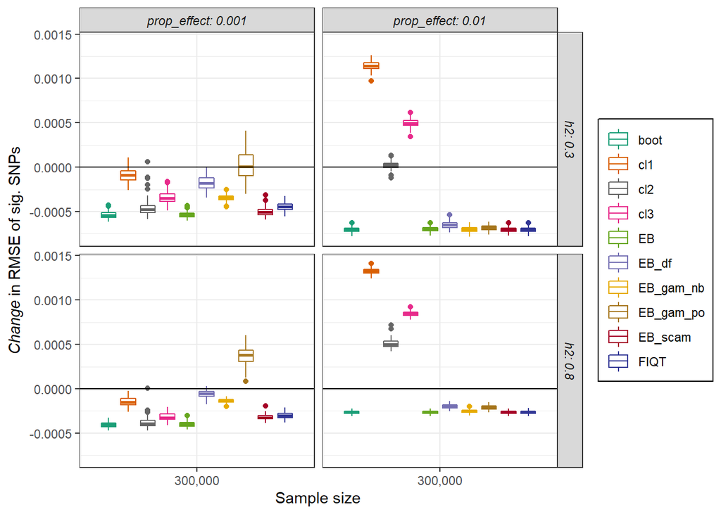

$~$ $~$ $~$ $~$

**Discussion:**

At the greater threshold of $5 \times 10^{-4}$, the first thing that comes to our attention is that positive values for change in MSE of significant SNPs are witnessed. This is in contrast to the previous simulation setting where the assumption of independence was present. There, at this threshold, all methods always led to better association estimates than the naive approach. The same was observed upon application of the methods to the UKBB real data sets. We will not place a great emphasis on the results at this threshold. That said, the most consistent and best performing methods here seem to be the bootstrap method, the original empirical Bayes method and the empirical Bayes method which uses shape constrained additive models (SCAMs).